# Lista 02 - Gabriela

### 2 - Consideracoes

#### Nenhum desses metodos eh superior ao outro. Existe o melhor/pior metodo para dado problema ou situacao, mas nao eh possivel generalizar e dizer que um sera sempre a melhor escolha. Como vimos, tanto a Inversao quanto o Box-Muller se mostraram eficientes para gerarem as distribuicoes de nossos objetivos (cauchy e normal).

#### Quanto a letra d) : Nao eh possivel verificar empiricamente o TCL pela Cauchy, pois a principal premissa desse teorema eh que a distribuicao dos dados apresente variancia finita, o que nao eh o caso da Cauchy.

## Questao 03 - Geracao de VAs pelo metodo da Aceitacao/Rejeicao

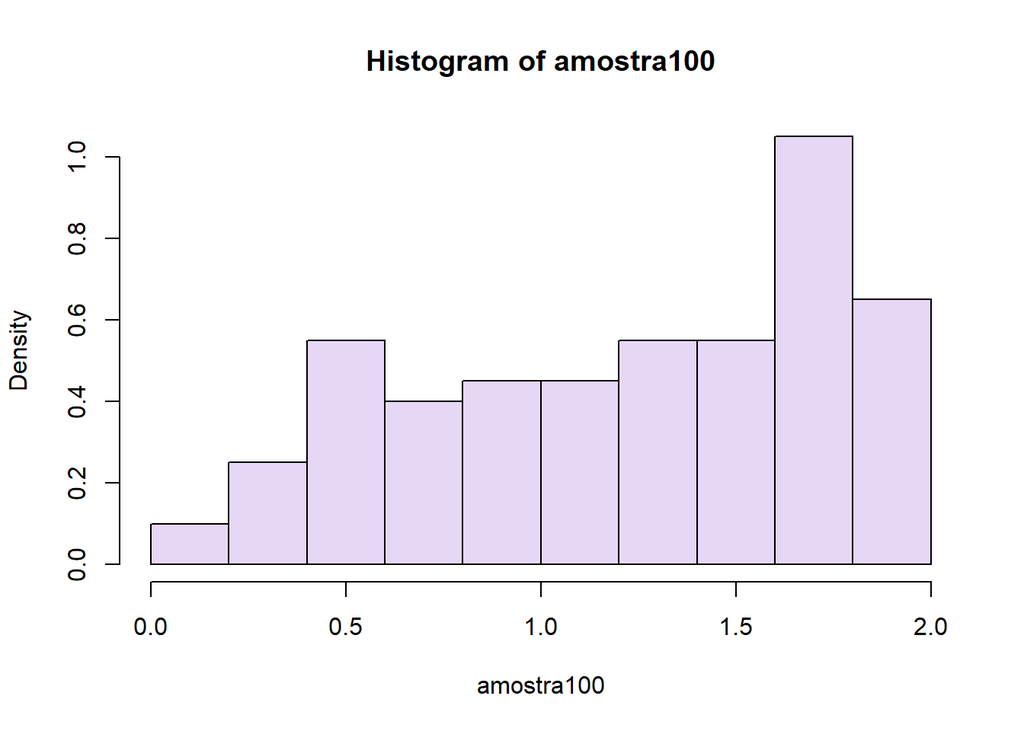

```r
# 1- Escolher a distribuicao de proposta (deve se aproximar da intencao)

g <- function(x) dnorm(x)

# 2 - Determinar constante m tal que M*g(x) >= f(x) para todo x no domínio de interesse.

f <- function(x){

  if (x >= 0 && x <= 1)
    return(d_coord<-30*((x**2)-(2*x**3)+x**4))

  else
    return(d_coord<-0)


}

M <- 2

# 3 - Gerar uma amostra aleatória x a partir da distribuição de proposta:

x <- rnorm(1)

# 4 - Gerar uma segunda amostra aleatória u a partir de uma distribuição uniforme no intervalo [0, M*g(x)]:


u <- runif(n = 1, min = 0, max = M*g(x))


# 5 - Aceitar ou rejeitar a amostra x:

amostra100<-numeric(100)
i<-1

while(i<=100){

if (u <= f(x)) {
  # Aceitar a amostra

  amostra100[i] <- f(x)
  i<-i+1

  x <- rnorm(1)
  u <- runif(n = 1, min = 0, max = M*g(x))


} else {
  # Rejeitar a amostra e repetir o processo (a partir da etapa 3)

  x <- rnorm(1)
  u <- runif(n = 1, min = 0, max = M*g(x))

}

}

hist(amostra100, freq = FALSE, col = '#E6D7F7')
```

[figure not shown]

```r
# a) Use o algoritmo de aceitação/rejeição baseado na distribuição uniforme.

rbeta_aceitacao_rejeicao <- function(n, a, b) {
  # Define a densidade da distribuição Beta(a,b)
  f_beta <- function(x) {
    if (x < 0 || x > 1) {
      return(0)
    }
    return(x^(a-1) * (1-x)^(b-1) / beta(a, b))
  }

  # Define a constante de normalização M
  M <- (a+b)^(-a-b+1) * max(1, (a-1) / (b-1))

  # Gerando amostras
  i <- 1
  x <- numeric(n)
  while (i <= n) {
    # Gerando uma amostra de x a partir de uma distribuição uniforme
    x_aleatorio <- runif(1)

    # Gerando uma amostra de y a partir de uma distribuição uniforme
    y_aleatorio <- runif(1, 0, M * f_beta(x_aleatorio))

    # Verificando se a amostra de y é menor que a densidade da distribuição Beta(a,b)
    if (y_aleatorio <= f_beta(x_aleatorio)) {
      x[i] <- x_aleatorio
      i <- i + 1
    }
  }

  # Retornando as amostras geradas
  return(x)
}

# Exemplo de uso

# Gerando 1000 amostras de uma distribuição Beta(2,5)
amostras_beta <- rbeta_aceitacao_rejeicao(1000, 2, 5)

# Plotando um histograma das amostras geradas
hist(amostras_beta, freq = FALSE, main = "Distribuição Beta(2,5)", xlab = "x")
```

```r
# b) Use o algoritmo de aceitação/rejeição baseado em beta gerada de acordo com a transformação apresentada no exemplo 2.2 de Robert e Casella (2010), pág. 69 (do pdf).


rbeta_transformacao <- function(n, a, b) {
  # Define a função f(x) e a função de envelope g(x)
  f <- function(x) x^(a-1) * (1-x)^(b-1) / beta(a,b)
  g <- function(x) 1

  # Define a constante de normalização M
  M <- max(f(seq(0,1,0.01)) / g(seq(0,1,0.01)))

  # Gerando amostras
  i <- 1
  x <- numeric(n)
  while (i <= n) {
    # Gerando uma amostra de y a partir de uma distribuição Beta(a,b)
    y <- rbeta(1, a, b)

    # Gerando uma amostra de u a partir de uma distribuição uniforme
    u <- runif(1)

    # Verificando se a amostra de u é menor ou igual a f(y)/(M*g(y))
    if (u <= f(y) / (M * g(y))) {
      x[i] <- y
      i <- i + 1
    }
  }

  # Retornando as amostras geradas
  return(x)
}

# c) Use o algoritmo de aceitação/rejeição baseado na distribuição normal truncada.

rnorm_truncada <- function(n, mu, sigma, a, b) {
  # Gerando amostras
  i <- 1
  x <- numeric(n)
  while (i <= n) {
    # Gerando uma amostra de y a partir de uma distribuição normal
    y <- mu + sigma * rnorm(1)

    # Verificando se a amostra de y está entre a e b
    if (y >= a && y <= b) {
      x[i] <- y
      i <- i + 1
    }
  }

  # Retornando as amostras geradas
  return(x)
}
```

[figure not shown]

```r
# Define os parâmetros das distribuições
a <- 2
b <- 5
mu <- 0
sigma <- 1
a_trunc <- 0.2
b_trunc <- 0.8

# Gera as amostras usando o algoritmo de aceitação/rejeição com distribuição uniforme
amostras_uniforme <- rbeta_aceitacao_rejeicao(1000, a, b)

# Gera as amostras usando o algoritmo de aceitação/rejeição com transformação beta
amostras_transformacao <- rbeta_transformacao(1000, a, b)

# Gera as amostras usando o algoritmo de aceitação/rejeição com distribuição normal truncada
amostras_truncada <- rnorm_truncada(1000, mu, sigma, a_trunc, b_trunc)

# Cria um data frame com as amostras geradas
df <- data.frame(
  amostras = c(amostras_uniforme, amostras_transformacao, amostras_truncada),
  metodo = rep(c("Uniforme", "Transformação Beta", "Normal Truncada"), each = 1000),
  regiao = rep(c("Aceitação", "Rejeição"), each = 500),
  tipo = rep(c("Beta", "Beta", "Normal"), each = 1000)
)



# Calcula a porcentagem de pontos gerados em cada região
porcentagem_regiao <- aggregate(df, by = list(df$metodo), FUN = function(x) {
  data.frame(
    porcentagem = c(
      sum(df$regiao == "Aceitação") / nrow(df),
      sum(df$regiao == "Rejeição") / nrow(df)
    ),
    tipo = unique(df$tipo)[1]
  )
})

# Define as cores para as regiões de aceitação e rejeição
cores <- c("green", "red")

# Define o intervalo de valores dos eixos
xlim <- range(df$amostras)
ylim <- c(0.5, 3.5)

# Plota um gráfico de pontos com os pontos de cada método
plot(df$amostras[df$metodo == "Rejeicao"], df$metodo[df$metodo == "Rejeicao"],
     col = cores[1], pch = 16, cex = 0.8, xlim = xlim, ylim = ylim, xlab = "Valor da amostra", ylab = "",
     main = "Comparação de métodos de amostragem")
points(df$amostras[df$metodo == "Aceitacao"], df$metodo[df$metodo == "Aceitacao"],
       col = cores[2], pch = 16, cex = 0.8)
legend("bottom", legend = c("Aceitação", "Rejeição"), col = cores, pch = 16)
```

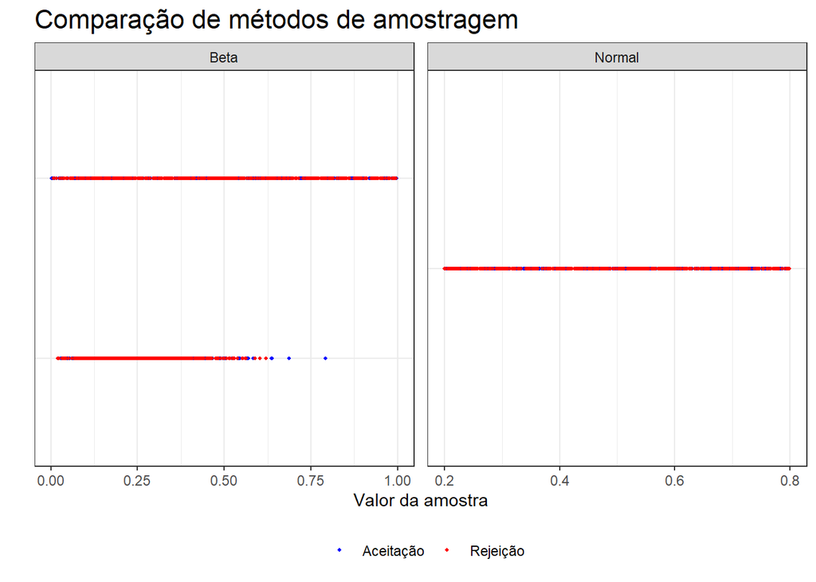

```r
# Plota um gráfico de pontos com os pontos de cada método
ggplot(df, aes(x = amostras, y = metodo, color = regiao)) +
  geom_point(size = 0.8) +
  facet_wrap(~tipo, scales = "free") +
  scale_color_manual(values = c("blue", "red"), labels = c("Aceitação", "Rejeição")) +
  theme_bw() +
  labs(
    title = "Comparação de métodos de amostragem",
    x = "Valor da amostra",
    y = "",
    color = ""
  ) +
  theme(
    axis.text.y = element_blank(),
    axis.ticks.y = element_blank(),
    legend.position = "bottom",
    legend.title = element_blank(),
    plot.title = element_text(size = 16)
  )
```

```r
# Imprime a porcentagem de pontos gerados em cada região
print(porcentagem_regiao)
```

```
##              Group.1 amostras   metodo   regiao     tipo
## 1    Normal Truncada 0.5, 0.5 0.5, 0.5 0.5, 0.5 0.5, 0.5
## 2 Transformação Beta 0.5, 0.5 0.5, 0.5 0.5, 0.5 0.5, 0.5
## 3           Uniforme 0.5, 0.5 0.5, 0.5 0.5, 0.5 0.5, 0.5
```

## Questao 05 - Simulacao de VA com Distribuicao Condicional

```r
# Seja X uma variável aleatória exponencial com média 1. Crie um código com um
# algoritmo eficiente para simular uma variável aleatória cuja distribuição é a
# distribuição condicional de X, dado que X < 0,05, ou seja, cuja função de
# densidade de probabilidade é:

fdp <- function(x){

  if (x > 0 & x < 0.05)
    return(exp(-x)/1-exp(-0.05))

  else
    return(0)

}


fda <- function(x){

  if (x <= 0)
    return(0)

  if(x > 0 & x < 0.05)
    return(exp(-x)-exp(-1/20))

  else
    return(1)

}

q <- function(p) {
  ifelse(p <= 0, 0, ifelse(p > 1, 0.05, -log(1 - p*(1 - exp(-1/20)))))
}


gerador <- function(n = 1000){

  u = runif(n)
  x = q(u)

  return(x)

}

amostra<-gerador()

media_estimada<-mean(amostra) # valor da media amostral

f<-function(x) exp(-x)/1-exp(-0.05)
integral<-integrate(f, lower = 0, upper = 0.05)$value  # calcular o valor esperado
media_exata<-integral/(1 - exp(-0.05))

media_estimada
```

```
## [1] 0.02443377
```

```r
media_exata
```

```
## [1] 0.02479168
```

```r
# DIFERENCA

media_estimada - media_exata
```

```
## [1] -0.0003579004
```

## Questao 06 - Metodo da Composicao

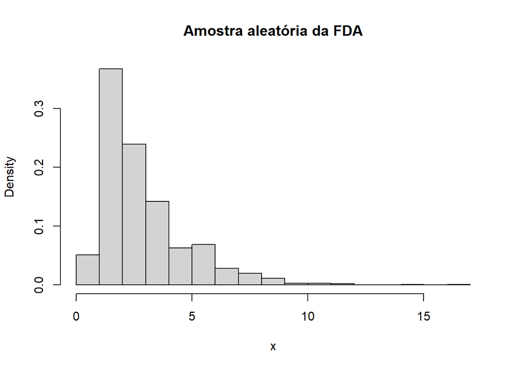

```r
# Definir a função de distribuição acumulada
F <- function(x) {
  if (x < 0 || x > Inf) {
    return(NA)
  } else if (x <= 1) {
    return(x * (1 - exp(-2*x)) / 3)
  } else {
    return((3 - exp(-2*x)) / 3)
  }
}

# Gerar amostra aleatória
n <- 1000 # tamanho da amostra
x <- rep(NA, n)
i <- 1
while (i <= n) {
  u <- runif(1)
  y <- rexp(1, rate = 1/2)
  if (u <= F(y)) {
    x[i] <- y
    i <- i + 1
  }
}

# Plotar o histograma da amostra gerada
hist(x, breaks = 20, freq = FALSE, main = "Amostra aleatória da FDA")
```